# Visual Analysis of US Broadband Disparities

## New York State Broadband Availability

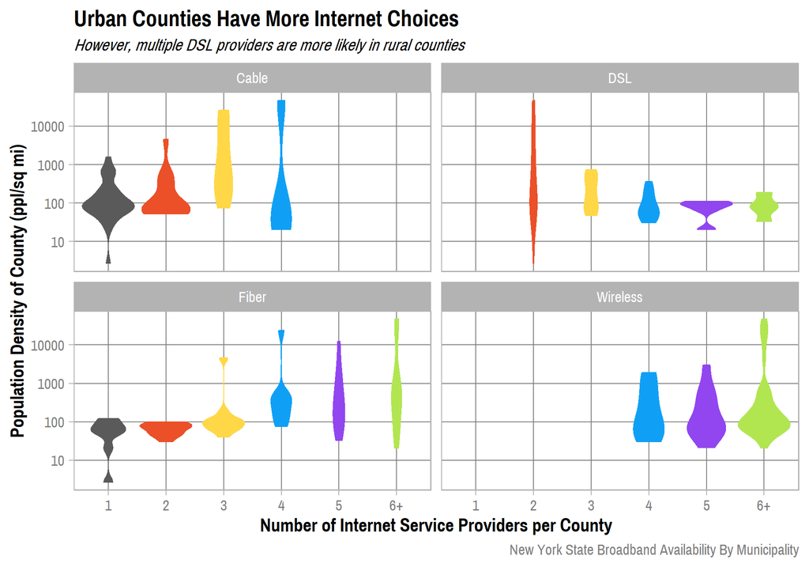

```r
ny_county_bb$num_prov = ny_county_bb$num_prov %>% ordered()
levels(ny_county_bb$num_prov) = list("1" = c(1), "2" = c(2), "3" = c(3), "4" = c(4), "5" = c(5), "6+" = c(6,7,8,9,10,11,12,13) )
ggplot(data = subset(ny_county_bb, tech != "Wireline"),
       aes(y = pop_dens, x = num_prov)) +
  geom_violin(aes(fill = num_prov,
                  color = num_prov)) +
  scale_fill_manual(values = color_pal(6)) +
  scale_color_manual(values = color_pal(6)) +
  scale_y_continuous(trans = "log10") +
  facet_wrap(~ tech) +
  labs(title = "Urban Counties Have More Internet Choices",
       subtitle = "However, multiple DSL providers are more likely in rural counties",
       x = "Number of Internet Service Providers per County",
       y = "Population Density of County (ppl/sq mi)",
       caption = "New York State Broadband Availability By Municipality") +
  theme_master() +
  theme(legend.position="none") +
  theme(panel.grid.minor = element_blank())
```

This data from New York offers some evidence that there are more ISPs the more population dense a county is. This suggests that ISPs are hesitant to enter a new market in rural areas, either because of the high barrier of entry, or due to existing ISPs in the market protecting their investment through tactics like exclusivity agreements with municipalities.

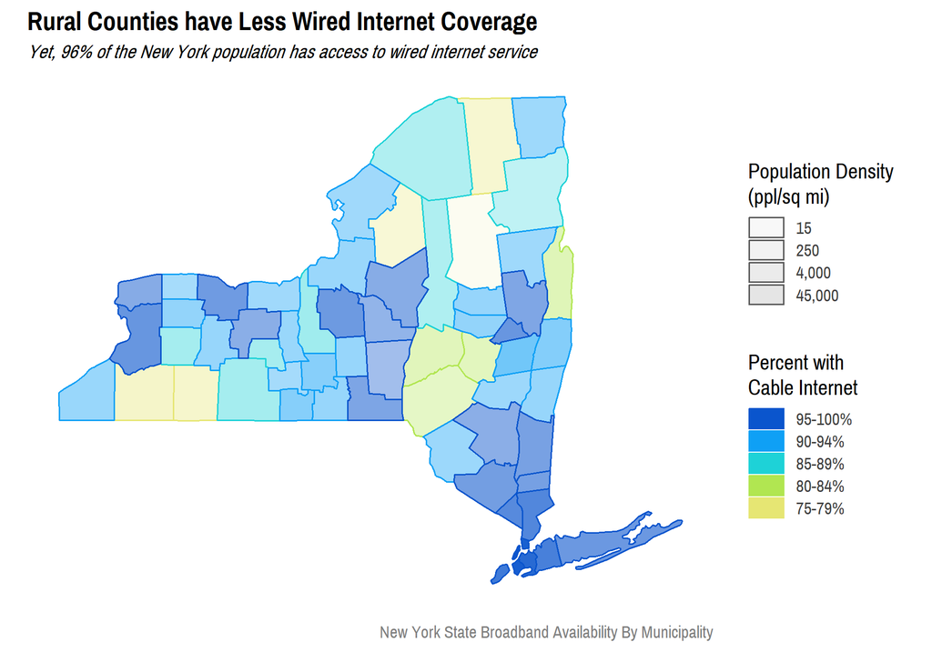

```r
avg_wired_int = sum(subset(ny_county_bb, tech == "Wireline")$`2010 Muni Population` * subset(ny_county_bb, tech == "Wireline")$perc_homes) / sum(subset(ny_county_bb, tech == "Wireline")$`2010 Muni Population`)

perc_homes_temp = cut(subset(ny_county_bb, tech == "Wireline")$perc_homes,
                   breaks = c(0.75, 0.8, 0.85, 0.9, 0.95, 1),
                   labels = c("75-79%", "80-84%", "85-89%","90-94%", "95-100%"))

ny_map + geom_sf(data = subset(ny_county_bb, tech == "Wireline"),
                 aes(fill = perc_homes_temp,
                     color = perc_homes_temp,
                     alpha = pop_dens),
                 size = 0.7) +
  scale_fill_manual(values = color_pal(5, type = "cool")) +
  scale_color_manual(values = color_pal(5, type = "cool")) +
  scale_alpha(trans = "log", range = c(0.1, 1), breaks = c(15, 250, 4000, 45000), labels = c("15", "250", "4,000", "45,000")) +
  guides(color = guide_legend(reverse=T), fill = guide_legend(reverse=T)) +
  labs(title = "Rural Counties have Less Wired Internet Coverage",
       subtitle = paste("Yet, ", round(avg_wired_int * 100), "% of the New York population has access to wired internet service", sep = ""),
       fill = "Percent with \nCable Internet",
       color = "Percent with \nCable Internet",
       alpha = "Population Density \n(ppl/sq mi)",
       caption = "New York State Broadband Availability By Municipality") +
    theme_map() +
  theme(axis.text = element_blank(),
        legend.position = "right")
```

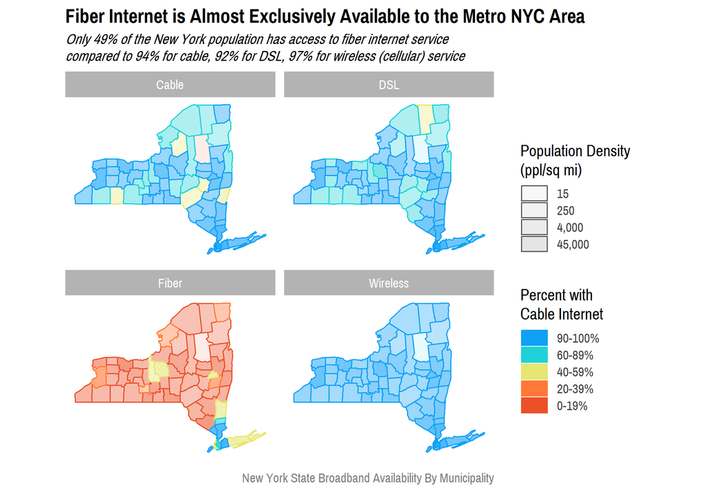

```r
avg_fiber_int = sum(subset(ny_county_bb, tech == "Fiber")$`2010 Muni Population` * subset(ny_county_bb, tech == "Fiber")$perc_homes) / sum(subset(ny_county_bb, tech == "Fiber")$`2010 Muni Population`)

avg_cable_int = sum(subset(ny_county_bb, tech == "Cable")$`2010 Muni Population` * subset(ny_county_bb, tech == "Cable")$perc_homes) / sum(subset(ny_county_bb, tech == "Cable")$`2010 Muni Population`)

avg_dsl_int = sum(subset(ny_county_bb, tech == "DSL")$`2010 Muni Population` * subset(ny_county_bb, tech == "DSL")$perc_homes) / sum(subset(ny_county_bb, tech == "DSL")$`2010 Muni Population`)

avg_wireless_int = sum(subset(ny_county_bb, tech == "Wireless")$`2010 Muni Population` * subset(ny_county_bb, tech == "Wireless")$perc_homes) / sum(subset(ny_county_bb, tech == "Wireless")$`2010 Muni Population`)

perc_homes_temp = cut(subset(ny_county_bb, tech != "Wireline")$perc_homes,
                   breaks = c(-0.1, 0.2, 0.4, 0.6, 0.8, 1),
                   labels = c("0-19%", "20-39%", "40-59%", "60-89%", "90-100%"))

ny_map + geom_sf(data = subset(ny_county_bb, tech != "Wireline"),
                 aes(fill = perc_homes_temp,
                     color = perc_homes_temp,
                     alpha = pop_dens),
                 size = 0.7) +
 scale_fill_manual(values = color_pal(5, type = "continuous")) +
  scale_color_manual(values = color_pal(5, type = "continuous")) +
  scale_alpha(trans = "log", range = c(0.1, 1), breaks = c(15, 250, 4000, 45000), labels = c("15", "250", "4,000", "45,000")) +
  guides(color = guide_legend(reverse=T), fill = guide_legend(reverse=T)) +
  facet_wrap(~ tech) +
  labs(title = "Fiber Internet is Almost Exclusively Available to the Metro NYC Area",
       subtitle = paste("Only ", round(avg_fiber_int * 100),
                        "% of the New York population has access to fiber internet service \ncompared to ",
                        round(avg_cable_int * 100), "% for cable, " ,
                        round(avg_dsl_int * 100), "% for DSL, " ,
                        round(avg_wireless_int * 100), "% for wireless (cellular) service" , sep = ""),
       fill = "Percent with \nCable Internet",
       color = "Percent with \nCable Internet",
       alpha = "Population Density \n(ppl/sq mi)",
       caption = "New York State Broadband Availability By Municipality") +
    theme_map() +
  theme(axis.text = element_blank(),
        legend.position = "right")
```

While overall, New York has good cable internet coverage, there still are significant disparities between rural and urban counties when it comes to cable Internet access, according to the state’s own broadband survey. However, only a few counties in New York City and the metro area have high fiber Internet adoption rates.

## US Census - American Community Survey 2017

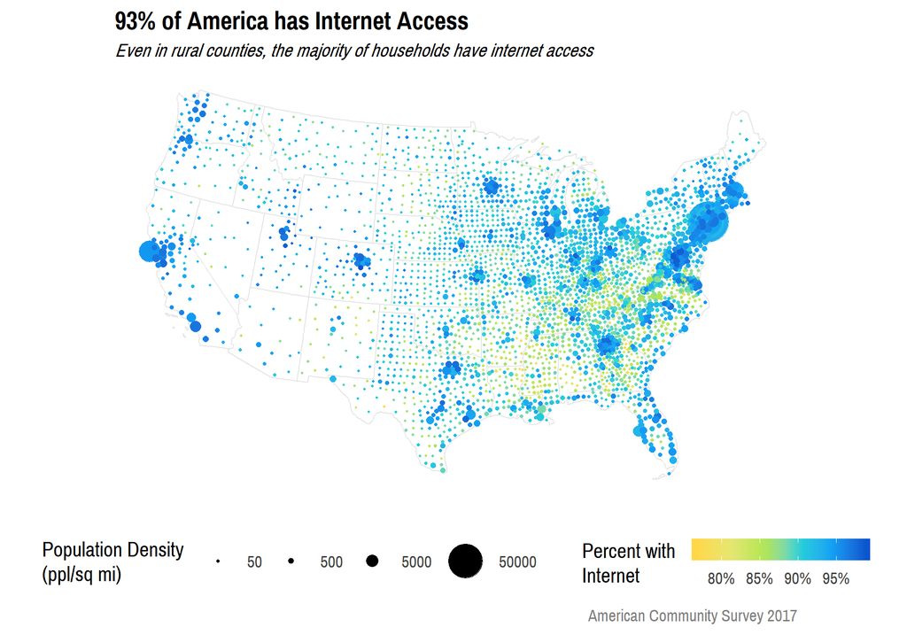

```r
avg_us_int = 1 - (sum(acs_17_mod$total_pop * acs_17_mod$no_inet) / sum(sum(acs_17_mod$total_pop)))

states_sf %>%
  ggplot() +
  geom_sf(color = "grey90", fill = "white") +
  coord_sf(crs = st_crs(102003)) +
  geom_point(data = acs_17_mod, aes(x = X,
                     y = Y,
                     color = (1- no_inet),
                     size = pop_dens)) +
  scale_color_gradientn(colors = color_pal(6, type = "cool"), labels = percent_format(accuracy = 1)) +
  scale_size(range = c(0.5, 15), breaks = c(50, 500, 5000, 50000)) +
  scale_alpha(range = c(1.0, 0.05)) +
  labs(title = paste(round(avg_us_int * 100), "% of America has Internet Access", sep = ""),
       subtitle = "Even in rural counties, the majority of households have internet access",
      color = "Percent with \nInternet",
       size = "Population Density \n(ppl/sq mi)",
      caption = "American Community Survey 2017") +
   theme_map() +
  theme(axis.text = element_blank())
```

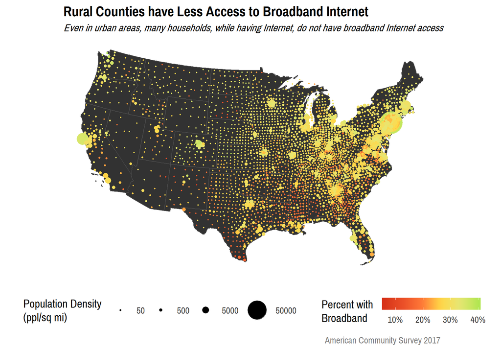

```r
states_sf %>%
  ggplot() +
  geom_sf(color = "grey30", fill = "#323232") +
  coord_sf(crs = st_crs(102003)) +
  geom_point(data = acs_17_mod, aes(x = X,
                     y = Y,
                     color = broadband_any,
                     size = pop_dens)) +
  scale_color_gradientn(colors = color_pal(6, type = "warm", reverse = TRUE), labels = percent_format(accuracy = 1)) +
  scale_size(range = c(0.5, 15), breaks = c(50, 500, 5000, 50000)) +
  scale_alpha(range = c(1.0, 0.05)) +
  labs(title = "Rural Counties have Less Access to Broadband Internet",
       subtitle = "Even in urban areas, many households, while having Internet, do not have broadband Internet access",
      color = "Percent with \nBroadband",
       size = "Population Density \n(ppl/sq mi)",
      caption = "American Community Survey 2017") +
  theme_map() +
  theme(axis.text = element_blank())
```

In rural counties in the United States, while most households have Internet access, many do not have Internet that meets the minimum speed requirements to be considered broadband Internet. However, this varies across the country. For example, Utah has much higher percentages of households for overall Internet access and broadband Internet access than many other rural states. In fact, despite its vastness, the western United States overall has much better accessibility to high-speed internet than other areas, most notably the rural South.

## Works Cited

Fingas, Jon. 2018. “Microsoft Says the Rural Broadband Divide Is Worse Than You Think.” *Engadget*. https://www.engadget.com/2018/12/05/microsoft-study-on-rural-broadband-shortfall/.

Kang, Cecilia. 2017. “How to Give Rural America Broadband? Look to the Early 1900s.” *The New York Times*. https://www.nytimes.com/2016/08/08/technology/how-to-give-rural-america-broadband-look-to-the-early-1900s.html.

Lenz, Lyz. 2018. “Iowa: Rural Broadband, and the Unknown Costs of the Digital Divide.” *Colombia Journalism Review*. https://www.cjr.org/special_report/midterms-2018-iowa-rural-broadband.php/.